# wsf model

M. Newbery & E. Bendall

28/02/2021

```r
knitr::opts_chunk$set(echo = TRUE, fig.width=8, fig.height=6)

library(here)
library(dplyr)
library(ggplot2)
library(mgcv)
library(readxl)
library(stringr)
library(tidyr)
library(bayesplot)
library(rstan)
library(brms)
library(tidybayes)
library(RColorBrewer)
library(car)
###### Some helper functions courtesy of Michael Bedward #####


#These options help Stan run faster (Stan is the machinery under the hood of brms):

rstan_options(auto_write = TRUE)
options(mc.cores = parallel::detectCores())

# Make sure the scales package is available (it should be if ggplot is installed)
requireNamespace("scales")

# Default graph theme - white background
theme_set( theme_bw() )

set.seed(42)


# Set to TRUE to force models to be refitted
REFIT_MODELS <- FALSE


# Create a folder for fitted models if one does not already exist
FittedModelsPath <- here("fitted_models")
if (!dir.exists(FittedModelsPath)) {
  dir.create(FittedModelsPath)
}


# Load brms if it is installed (requires Stan software and the rstan package).
# If not installed, HAS_BRMS will be set to FALSE.
HAS_BRMS <- suppressWarnings(
  require("brms", quietly = TRUE)
)


# Save a graph to a PDF file
gg_pdf <- function(plot, filename, size = pagesize("A4", "landscape", "cm")) {

  if (!inherits(size, "pagesize")) stop("The size argument should be a pagesize (list) object")

  ggsave(
    filename,
    plot,
    width = size$width,
    height = size$height,
    units = size$units)
}


# Calculate highest posterior density interval for a vector of values (e.g. calculate credible intervals)
hpdi.vec <- function (x, prob = 0.95) {
  n <- length(x)
  if (n <= 1) stop("x must have more than 1 element")
  x <- sort(x)

  gap <- max(1, min(n - 1, round(n * prob)))
  init <- 1:(n - gap)

  inds <- which.min(x[init + gap] - x[init])

  out <- c(lower = x[inds], upper = x[inds + gap])
  out
}
```

## model for wsf

```r
load("prelim.canopy.data")

dat.model.wsf <- dat.epi %>%
  filter(veg == "wsf") %>%
  filter(sev == "Mod"|sev == "High")%>%

  mutate(sev = factor(sev, levels = c("Mod", "High"),
                           labels = c("Mod", "High")))
```

### model code

```r
library(future)
plan(multiprocess)
model.brms.wsf <- brm(
    loc ~ sev + group + dbh + (1|site),
  data = dat.model.wsf,
  family = bernoulli(),
  chains = 4,
  warmup = 5000,
  iter = 20000,
  control = list(adapt_delta = 0.99,
                 max_treedepth = 12))
plan(sequential)



summary(model.brms.wsf)
```

```
##  Family: bernoulli
##   Links: mu = logit
## Formula: loc ~ sev + group + dbh + (1 | site)
##    Data: dat.model.wsf (Number of observations: 69)
## Samples: 4 chains, each with iter = 20000; warmup = 5000; thin = 1;
##          total post-warmup samples = 60000
##
## Group-Level Effects:
## ~site (Number of levels: 6)
##               Estimate Est.Error l-95% CI u-95% CI Rhat Bulk_ESS Tail_ESS
## sd(Intercept)     1.23      0.89     0.08     3.47 1.00    12607    16564
##
## Population-Level Effects:
##             Estimate Est.Error l-95% CI u-95% CI Rhat Bulk_ESS Tail_ESS
## Intercept      -0.27      2.10    -4.75     3.67 1.00    23718    21064
## sevHigh         1.01      1.74    -2.21     4.80 1.00    23520    20799
## groupAbsent     1.71      1.72    -1.55     5.43 1.00    23573    21921
## dbh            -0.03      0.01    -0.06    -0.00 1.00    47828    36523
##
## Samples were drawn using sampling(NUTS). For each parameter, Bulk_ESS
## and Tail_ESS are effective sample size measures, and Rhat is the potential
## scale reduction factor on split chains (at convergence, Rhat = 1).
```

Model summary (similar to that from lme4::glmer).

```r
  summary(model.brms.wsf)
```

```
##  Family: bernoulli
##   Links: mu = logit
## Formula: loc ~ sev + group + dbh + (1 | site)
##    Data: dat.model.wsf (Number of observations: 69)
## Samples: 4 chains, each with iter = 20000; warmup = 5000; thin = 1;
##          total post-warmup samples = 60000
##
## Group-Level Effects:
## ~site (Number of levels: 6)
##               Estimate Est.Error l-95% CI u-95% CI Rhat Bulk_ESS Tail_ESS
## sd(Intercept)     1.23      0.89     0.08     3.47 1.00    12607    16564
##
## Population-Level Effects:
##             Estimate Est.Error l-95% CI u-95% CI Rhat Bulk_ESS Tail_ESS
## Intercept      -0.27      2.10    -4.75     3.67 1.00    23718    21064
## sevHigh         1.01      1.74    -2.21     4.80 1.00    23520    20799
## groupAbsent     1.71      1.72    -1.55     5.43 1.00    23573    21921
## dbh            -0.03      0.01    -0.06    -0.00 1.00    47828    36523
##
## Samples were drawn using sampling(NUTS). For each parameter, Bulk_ESS
## and Tail_ESS are effective sample size measures, and Rhat is the potential
## scale reduction factor on split chains (at convergence, Rhat = 1).
```

These values are very similar to those produced by lme4::glmer. Rhat = 1 which is good. If Rhat is not 1 then something is not fitting well

Graphical summaries of fitted parameters (densities and trace plots). Again these are mostly for model checking. They should look like hairy caterpillars

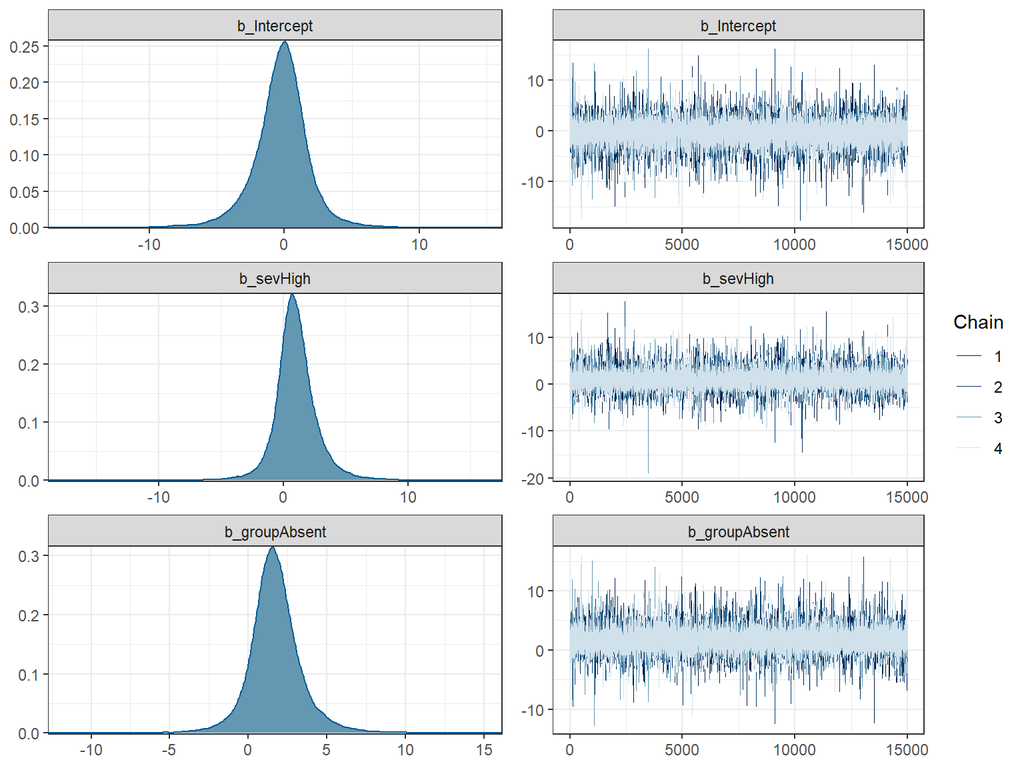

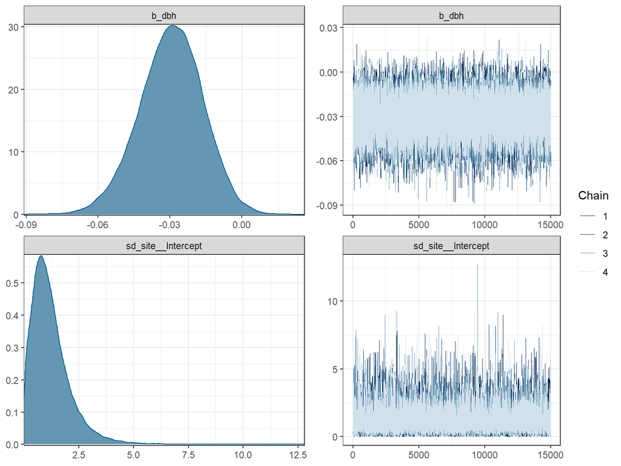

```r
if (HAS_BRMS) {
  plot(model.brms.wsf, N=3, ask = FALSE, newpage = FALSE)
}
```

### wsf predictions

```r
### create all unique combinations of variables (use expand.grid when cont. vars.)
post.wsf <- expand.grid(
  dbh = seq(15, 80, 0.5),
  sev = levels(dat.model.wsf$sev),
  group = levels(dat.model.wsf$group)
          ) %>%

### add fitted draws -

  tidybayes::add_fitted_draws(model.brms.wsf, n = 5000, re_formula = NA) %>%
  ungroup() %>%

  select(iter=.draw, dbh, sev, group, Probability = .value)
```

```r
## here we constrain the predictions to sensible values of DBH
effect1 <- post.wsf %>%

  filter(dbh >= 15 & dbh <= 80) %>%

  tidyr::spread(sev, Probability)




diff1 <- effect1 %>%

  mutate(diff_Extreme = High,
         diff_Moderate = Mod) %>%

  select(dbh, group, starts_with("diff"))

# convert to long format for ggplot
dat.gg1 <- diff1 %>%
  tidyr::gather(sev, diff, -dbh, -group) %>%
  mutate(sev = factor(str_replace(sev, "diff_", ""))) %>%
  mutate(sev = factor(str_replace(sev, "_", "/")))


## main summary stats to be used for plotting, similar to confidence intervals, but 50% and 95% of posterior predictions


## for severity plot
x.stats1 <- dat.gg1 %>%
  group_by(dbh, sev) %>%
    summarize(mid = median(diff),
            lwr95 = hpdi.vec(diff, 0.95)[1],
            upr95 = hpdi.vec(diff, 0.95)[2],
            lwr50 = hpdi.vec(diff, 0.50)[1],
            upr50 = hpdi.vec(diff, 0.50)[2])
## for euc group plot
x.stats2 <- dat.gg1 %>%
  group_by(dbh, group) %>%
    summarize(mid = median(diff),
            lwr95 = hpdi.vec(diff, 0.95)[1],
            upr95 = hpdi.vec(diff, 0.95)[2],
            lwr50 = hpdi.vec(diff, 0.50)[1],
            upr50 = hpdi.vec(diff, 0.50)[2])
```

## plot

```r
library(ggthemes)
```

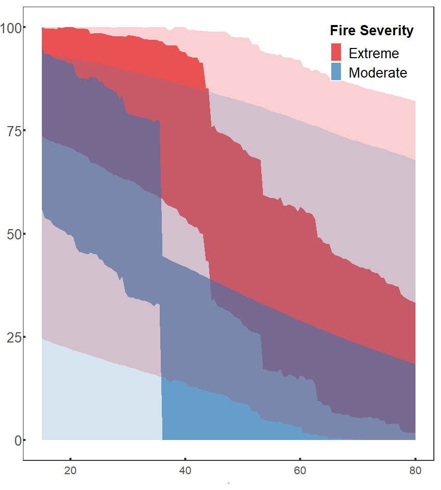

```r
My_Theme = theme(
  plot.title = element_text(size = 8, face = "bold", hjust = 0.5),
  axis.title.y = element_text(size = 8, face = "bold", vjust = 4.5),
  axis.text.y = element_text(size = 10, margin = unit(c(0.1, 0.1, 0.1, -0.2), "cm")),
  axis.text.x = element_text(size = 8, vjust = 0, margin = unit(c(0.15, 0.1, 0.1, 0.1), "cm")),
  axis.title.x = element_text(size = 0, face = "bold", vjust = -0.6),
  strip.text.x = element_text(size = 11),
  strip.text.y = element_text(size = 11),
  strip.text = element_text(size = 11),
  strip.background = element_blank(),
  panel.background = element_blank(),
  strip.placement = "inside",
  axis.ticks.length = unit(-0.07, "cm"),
  axis.ticks = element_line(size = 0.8),
  panel.grid.minor.x = element_blank(),
  panel.grid.major.x = element_blank(),
  panel.grid.minor.y = element_blank(),
  panel.grid.major.y = element_blank(),
  legend.position = c(0.85,0.9),
  legend.title = element_text(size = 10, hjust = 0.6, face = "bold"),
  legend.text = element_text(size = 10),
  legend.key.width = unit(0.3, "cm"),
  legend.key.height = unit(0.5, "cm"),
  legend.background = element_blank(),
  plot.margin = unit(c(5, 5, 5, 5), "pt"))


wsf.sev.plot <- ggplot(data = dat.gg1, aes (x = dbh)) +

 My_Theme +

  geom_ribbon(data = x.stats1, aes(ymin = lwr50, ymax = upr50, fill = sev), alpha = 0.7) +

  geom_ribbon(data = x.stats1, aes(ymin = lwr95, ymax = upr95, fill = sev), alpha = 0.2) +



  labs( fill = "Fire Severity") +


  scale_y_continuous(labels = scales::percent_format(suffix = "", accuracy = 1), limits = c(0, 1)) +

  scale_fill_brewer(palette = "Set1")




wsf.sev.plot
```

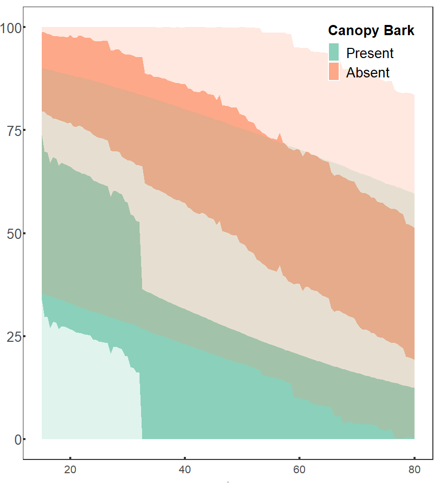

```r
library(ggthemes)


My_Theme = theme(
  plot.title = element_text(size = 8, face = "bold", hjust = 0.5),
  axis.title.y = element_text(size = 8, face = "bold", vjust = 4.5),
  axis.text.y = element_text(size = 10, margin = unit(c(0.1, 0.1, 0.1, -0.2), "cm")),
  axis.text.x = element_text(size = 8, vjust = 0, margin = unit(c(0.15, 0.1, 0.1, 0.1), "cm")),
  axis.title.x = element_text(size = 0, face = "bold", vjust = -0.6),
  strip.text.x = element_text(size = 11),
  strip.text.y = element_text(size = 11),
  strip.text = element_text(size = 11),
  strip.background = element_blank(),
  panel.background = element_blank(),
  strip.placement = "inside",
  axis.ticks.length = unit(-0.07, "cm"),
  axis.ticks = element_line(size = 0.8),
  panel.grid.minor.x = element_blank(),
  panel.grid.major.x = element_blank(),
  panel.grid.minor.y = element_blank(),
  panel.grid.major.y = element_blank(),
  legend.position = c(0.85,0.9),
  legend.title = element_text(size = 10, hjust = 0.6, face = "bold"),
  legend.text = element_text(size = 10),
  legend.key.width = unit(0.3, "cm"),
  legend.key.height = unit(0.5, "cm"),
  legend.background = element_blank(),
  plot.margin = unit(c(5, 5, 5, 5), "pt"))


wsf.group.plot <- ggplot(data = dat.gg1, aes (x = dbh)) +

 My_Theme +

  geom_ribbon(data = x.stats2, aes(ymin = lwr50, ymax = upr50, fill = group), alpha = 0.7) +

  geom_ribbon(data = x.stats2, aes(ymin = lwr95, ymax = upr95, fill = group), alpha = 0.2) +



  labs(fill = "Canopy Bark") +


  scale_y_continuous(labels = scales::percent_format(suffix = "", accuracy = 1), limits = c(0, 1)) +

  scale_fill_brewer(palette = "Set2")




wsf.group.plot
```

```r
library(ggpubr)
library(egg)
```

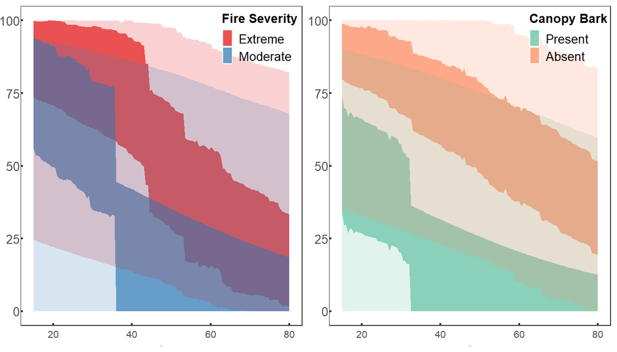

```r
library(cowplot)
combined.fig <- egg::ggarrange(wsf.sev.plot, wsf.group.plot, nrow = 1, ncol = 2)
```

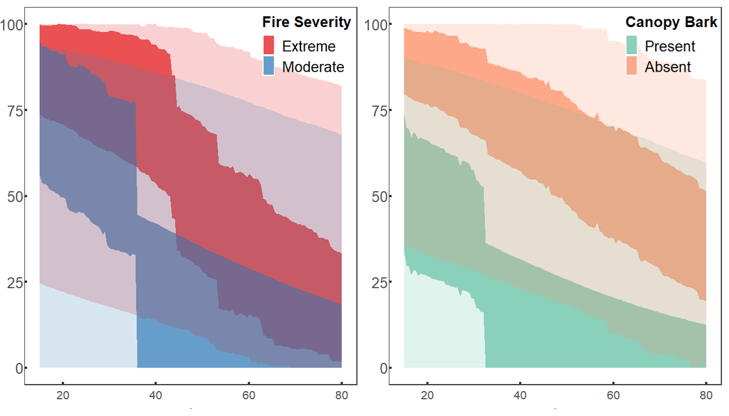

```r
combined.fig
```

```r
ggsave2("wsf.combined.plot.png", plot = combined.fig)
```

Probability at different values of DBH

```r
means <- dat.gg1 %>%
  mutate(
    dbh = case_when(
         dbh <= 19 ~ "<20",
         dbh >= 20 & dbh < 25 ~ "20-25",
         dbh >= 25 & dbh < 35 ~ "25-35",
         dbh >= 35 & dbh < 45 ~ "35-45",
         dbh >= 45 & dbh < 55 ~ "45-55",
         dbh >= 55 & dbh < 80 ~ "55-80"))


means <- means %>%
  group_by(group, dbh, sev) %>%
  summarize(prob = mean(diff))
knitr::kable(means, digits = 3)
```

| group | dbh | sev | prob |
| --- | --- | --- | --- |
| Present | <20 | Extreme | 0.545 |
| Present | <20 | Moderate | 0.383 |
| Present | 20-25 | Extreme | 0.513 |
| Present | 20-25 | Moderate | 0.358 |
| Present | 25-35 | Extreme | 0.468 |
| Present | 25-35 | Moderate | 0.324 |
| Present | 35-45 | Extreme | 0.408 |
| Present | 35-45 | Moderate | 0.282 |
| Present | 45-55 | Extreme | 0.351 |
| Present | 45-55 | Moderate | 0.244 |
| Present | 55-80 | Extreme | 0.265 |
| Present | 55-80 | Moderate | 0.189 |
| Present | NA | Extreme | 0.371 |
| Present | NA | Moderate | 0.263 |
| Absent | <20 | Extreme | 0.817 |
| Absent | <20 | Moderate | 0.681 |
| Absent | 20-25 | Extreme | 0.800 |
| Absent | 20-25 | Moderate | 0.654 |
| Absent | 25-35 | Extreme | 0.772 |
| Absent | 25-35 | Moderate | 0.613 |
| Absent | 35-45 | Extreme | 0.730 |
| Absent | 35-45 | Moderate | 0.555 |
| Absent | 45-55 | Extreme | 0.681 |
| Absent | 45-55 | Moderate | 0.494 |
| Absent | 55-80 | Extreme | 0.583 |
| Absent | 55-80 | Moderate | 0.391 |
| Absent | NA | Extreme | 0.658 |
| Absent | NA | Moderate | 0.495 |

## difference calculations

```r
effect1.sev.avg <- post.wsf %>%


  filter(dbh >= 25 & dbh <= 26) %>%

  tidyr::spread(sev, Probability)

effect1.sev.lrg <- post.wsf %>%


  filter(dbh >= 50 & dbh <= 51) %>%


  tidyr::spread(sev, Probability)

effect1.group.avg <- post.wsf %>%


  filter(dbh >= 25 & dbh <= 26) %>%

  tidyr::spread(group, Probability)

effect1.group.lrg <- post.wsf %>%


  filter(dbh >= 50 & dbh <= 51) %>%


  tidyr::spread(group, Probability)
```

```r
## average sized trees
diffs1.sev.avg <- effect1.sev.avg %>%

  mutate(diff_sev = (High -  Mod)) %>%

  select(group, starts_with("diff"))

## larger trees

diffs1.sev.lrg <- effect1.sev.lrg %>%

  mutate(diff_sev = (High -  Mod)) %>%

  select(group, starts_with("diff"))

## average sized trees
diffs1.group.avg <- effect1.group.avg %>%

  mutate(diff_group = (Present - Absent)) %>%

  select(sev, starts_with("diff"))

## larger trees

diffs1.group.lrg <- effect1.group.lrg %>%

  mutate(diff_group = (Present - Absent)) %>%

  select(sev, starts_with("diff"))
```

```r
# convert to long format for ggplot


### average sized trees
dat.gg1.sev.avg <- diffs1.sev.avg %>%
  tidyr::gather(sev, diff, -group) %>%
  mutate(sev = factor(str_replace(sev, "diff_", ""))) %>%
  mutate(sev = factor(str_replace(sev, "_", "/")))


x.stats1.sev.avg <- dat.gg1.sev.avg %>%
  group_by(group, sev) %>%
    summarize(mid = median(diff),
            lwr95 = hpdi.vec(diff, 0.95)[1],
            upr95 = hpdi.vec(diff, 0.95)[2],
            lwr50 = hpdi.vec(diff, 0.50)[1],
            upr50 = hpdi.vec(diff, 0.50)[2])
## larger trees
dat.gg1.sev.lrg <- diffs1.sev.lrg %>%
  tidyr::gather(sev, diff, -group) %>%
  mutate(sev = factor(str_replace(sev, "diff_", ""))) %>%
  mutate(sev = factor(str_replace(sev, "_", "/")))


x.stats1.sev.lrg <- dat.gg1.sev.lrg %>%
  group_by(group, sev) %>%
    summarize(mid = median(diff),
            lwr95 = hpdi.vec(diff, 0.95)[1],
            upr95 = hpdi.vec(diff, 0.95)[2],
            lwr50 = hpdi.vec(diff, 0.50)[1],
            upr50 = hpdi.vec(diff, 0.50)[2])
### average sized trees
dat.gg1.group.avg <- diffs1.group.avg %>%
  tidyr::gather(group, diff, -sev) %>%
  mutate(group = factor(str_replace(group, "diff_", ""))) %>%
  mutate(group = factor(str_replace(group, "_", "/")))


x.stats1.group.avg <- dat.gg1.group.avg %>%
  group_by(sev, group) %>%
    summarize(mid = median(diff),
            lwr95 = hpdi.vec(diff, 0.95)[1],
            upr95 = hpdi.vec(diff, 0.95)[2],
            lwr50 = hpdi.vec(diff, 0.50)[1],
            upr50 = hpdi.vec(diff, 0.50)[2])
## larger trees
dat.gg1.group.lrg <- diffs1.group.lrg %>%
  tidyr::gather(group, diff, -sev) %>%
  mutate(group = factor(str_replace(group, "diff_", ""))) %>%
  mutate(group = factor(str_replace(group, "_", "/")))


x.stats1.group.lrg <- dat.gg1.group.lrg %>%
  group_by(sev, group) %>%
    summarize(mid = median(diff),
            lwr95 = hpdi.vec(diff, 0.95)[1],
            upr95 = hpdi.vec(diff, 0.95)[2],
            lwr50 = hpdi.vec(diff, 0.50)[1],
            upr50 = hpdi.vec(diff, 0.50)[2])
```

### difference for average sized trees (Severity)

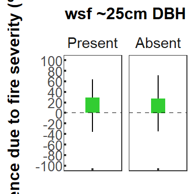

```r
My_Theme = theme(
  plot.title = element_text(size = 12, face = "bold", hjust = 0.5),
  axis.title.y = element_text(size = 12, face = "bold"),
  axis.text.y = element_text(size = 10, margin = unit(c(0.1, 0.1, 0.1, -0.2), "cm")),
  axis.text.x = element_blank(),
  axis.title.x = element_text(size = 12, face = "bold", vjust = -0.6),
  strip.text.x = element_text(size = 11),
  strip.text.y = element_text(size = 11),
  strip.text = element_text(size = 11),
  strip.background = element_blank(),
  panel.background = element_blank(),
  strip.placement = "inside",
  axis.ticks.length = unit(-0.07, "cm"),
  axis.ticks = element_line(size = 0.8),
  panel.grid.minor.x = element_blank(),
  panel.grid.major.x = element_blank(),
  panel.grid.minor.y = element_blank(),
  panel.grid.major.y = element_blank(),
  legend.position = "bottom",
  legend.title = element_text(size = 9, hjust = 0.6, face = "bold"),
  legend.text = element_text(size = 9),
  legend.key.width = unit(0.3, "cm"),
  legend.key.height = unit(0.5, "cm"),
  legend.background = element_blank(),
  plot.margin = unit(c(5, 5, 5, 5), "pt"))


diff.avg.sev.wsf <- ggplot(data = x.stats1.sev.avg, aes(x = sev)) +

  My_Theme +

  geom_linerange(aes(ymin = lwr95, ymax = upr95),
               size = 0.5, position = position_dodge(width = 0.6)) +

  geom_linerange(aes(ymin = lwr50, ymax = upr50),
               size = 5.0, show.legend = FALSE, position = position_dodge(width = 0.6), col = "limegreen") +


  labs(x = "", y = "Difference due to fire severity (%)\n", title = "wsf ~25cm DBH") +


  geom_hline(yintercept = 0, linetype = "dashed", alpha = 0.5) +


  scale_y_continuous(labels = scales::percent_format(suffix = "", accuracy = 1), limits = c(-1, 1), breaks = c(-1, -0.8, -0.6, -0.4, -0.2, 0, 0.2, 0.4, 0.6, 0.8, 1)) +

  facet_grid(~group) +

  coord_cartesian(ylim=c(-1, 1))

diff.avg.sev.wsf
```

## here we just see a numerical summary of the graph that we can use when writing results text.

## Change in difference for 25 cm trees

```r
dat.gg1.sev.avg %>%
  group_by(group, sev) %>%
  summarize(prob = mean(diff))
```

```
## # A tibble: 2 x 3
## # Groups:   group [2]
##   group   sev    prob
##   <fct>   <fct> <dbl>
## 1 Present sev   0.150
## 2 Absent  sev   0.152
```

Summary of magnitude of differences based on 50% and 95% highest posterior density intervals for 25cm trees

```r
x.stats1.sev.avg
```

```
## # A tibble: 2 x 7
## # Groups:   group [2]
##   group   sev     mid  lwr95 upr95    lwr50 upr50
##   <fct>   <fct> <dbl>  <dbl> <dbl>    <dbl> <dbl>
## 1 Present sev   0.151 -0.358 0.637  0.00721 0.293
## 2 Absent  sev   0.139 -0.346 0.716 -0.00783 0.270
```

### difference for larger trees

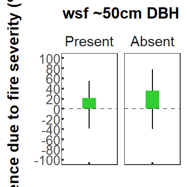

```r
My_Theme = theme(
  plot.title = element_text(size = 12, face = "bold", hjust = 0.5),
  axis.title.y = element_text(size = 12, face = "bold"),
  axis.text.y = element_text(size = 10, margin = unit(c(0.1, 0.1, 0.1, -0.2), "cm")),
  axis.text.x = element_blank(),
  axis.title.x = element_text(size = 12, face = "bold", vjust = -0.6),
  strip.text.x = element_text(size = 11),
  strip.text.y = element_text(size = 11),
  strip.text = element_text(size = 11),
  strip.background = element_blank(),
  panel.background = element_blank(),
  strip.placement = "inside",
  axis.ticks.length = unit(-0.07, "cm"),
  axis.ticks = element_line(size = 0.8),
  panel.grid.minor.x = element_blank(),
  panel.grid.major.x = element_blank(),
  panel.grid.minor.y = element_blank(),
  panel.grid.major.y = element_blank(),
  legend.position = "bottom",
  legend.title = element_text(size = 9, hjust = 0.6, face = "bold"),
  legend.text = element_text(size = 9),
  legend.key.width = unit(0.3, "cm"),
  legend.key.height = unit(0.5, "cm"),
  legend.background = element_blank(),
  plot.margin = unit(c(5, 5, 5, 5), "pt"))


diff.lrg.sev.wsf <- ggplot(data = x.stats1.sev.lrg, aes(x = sev)) +

  My_Theme +

  geom_linerange(aes(ymin = lwr95, ymax = upr95),
               size = 0.5, position = position_dodge(width = 0.6)) +

  geom_linerange(aes(ymin = lwr50, ymax = upr50),
               size = 5.0, show.legend = FALSE, position = position_dodge(width = 0.6), col = "limegreen") +


  labs(x = "", y = "Difference due to fire severity (%)\n", title = "wsf ~50cm DBH") +


  geom_hline(yintercept = 0, linetype = "dashed", alpha = 0.5) +


  scale_y_continuous(labels = scales::percent_format(suffix = "", accuracy = 1), limits = c(-1, 1), breaks = c(-1, -0.8, -0.6, -0.4, -0.2, 0, 0.2, 0.4, 0.6, 0.8, 1)) +
  coord_cartesian(ylim=c(-1, 1)) +

  facet_grid(~ group)

diff.lrg.sev.wsf
```

Change in difference for 50 cm trees

```r
dat.gg1.sev.lrg %>%
  group_by(group, sev) %>%
  summarize(prob = mean(diff))
```

```
## # A tibble: 2 x 3
## # Groups:   group [2]
##   group   sev    prob
##   <fct>   <fct> <dbl>
## 1 Present sev   0.105
## 2 Absent  sev   0.188
```

```r
x.stats1.sev.lrg
```

```
## # A tibble: 2 x 7
## # Groups:   group [2]
##   group   sev     mid  lwr95 upr95   lwr50 upr50
##   <fct>   <fct> <dbl>  <dbl> <dbl>   <dbl> <dbl>
## 1 Present sev   0.110 -0.390 0.547 0.00264 0.215
## 2 Absent  sev   0.188 -0.402 0.779 0.00737 0.364
```

### difference for average sized trees (Group)

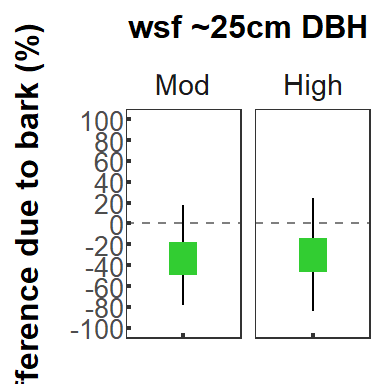

```r
My_Theme = theme(
  plot.title = element_text(size = 12, face = "bold", hjust = 0.5),
  axis.title.y = element_text(size = 12, face = "bold"),
  axis.text.y = element_text(size = 10, margin = unit(c(0.1, 0.1, 0.1, -0.2), "cm")),
  axis.text.x = element_blank(),
  axis.title.x = element_text(size = 12, face = "bold", vjust = -0.6),
  strip.text.x = element_text(size = 11),
  strip.text.y = element_text(size = 11),
  strip.text = element_text(size = 11),
  strip.background = element_blank(),
  panel.background = element_blank(),
  strip.placement = "inside",
  axis.ticks.length = unit(-0.07, "cm"),
  axis.ticks = element_line(size = 0.8),
  panel.grid.minor.x = element_blank(),
  panel.grid.major.x = element_blank(),
  panel.grid.minor.y = element_blank(),
  panel.grid.major.y = element_blank(),
  legend.position = "bottom",
  legend.title = element_text(size = 9, hjust = 0.6, face = "bold"),
  legend.text = element_text(size = 9),
  legend.key.width = unit(0.3, "cm"),
  legend.key.height = unit(0.5, "cm"),
  legend.background = element_blank(),
  plot.margin = unit(c(5, 5, 5, 5), "pt"))


diff.avg.group.wsf <- ggplot(data = x.stats1.group.avg, aes(x = group)) +

  My_Theme +

  geom_linerange(aes(ymin = lwr95, ymax = upr95),
               size = 0.5, position = position_dodge(width = 0.6)) +

  geom_linerange(aes(ymin = lwr50, ymax = upr50),
               size = 5.0, show.legend = FALSE, position = position_dodge(width = 0.6), col = "limegreen") +


  labs(x = "", y = "Difference due to bark (%)\n", title = "wsf ~25cm DBH") +


  geom_hline(yintercept = 0, linetype = "dashed", alpha = 0.5) +


  scale_y_continuous(labels = scales::percent_format(suffix = "", accuracy = 1), limits = c(-1, 1), breaks = c(-1, -0.8, -0.6, -0.4, -0.2, 0, 0.2, 0.4, 0.6, 0.8, 1)) +

  facet_grid(~sev) +

  coord_cartesian(ylim=c(-1, 1))

diff.avg.group.wsf
```

## here we just see a numerical summary of the graph that we can use when writing results text.

## Change in difference for 25 cm trees

```r
dat.gg1.group.avg %>%
  group_by(sev, group) %>%
  summarize(prob = mean(diff))
```

```
## # A tibble: 2 x 3
## # Groups:   sev [2]
##   sev   group   prob
##   <fct> <fct>  <dbl>
## 1 Mod   group -0.294
## 2 High  group -0.295
```

Summary of magnitude of differences based on 50% and 95% highest posterior density intervals for 25cm trees

```r
x.stats1.group.avg
```

```
## # A tibble: 2 x 7
## # Groups:   sev [2]
##   sev   group    mid  lwr95 upr95  lwr50  upr50
##   <fct> <fct>  <dbl>  <dbl> <dbl>  <dbl>  <dbl>
## 1 Mod   group -0.310 -0.778 0.180 -0.494 -0.174
## 2 High  group -0.300 -0.841 0.245 -0.463 -0.136
```

### difference for larger trees

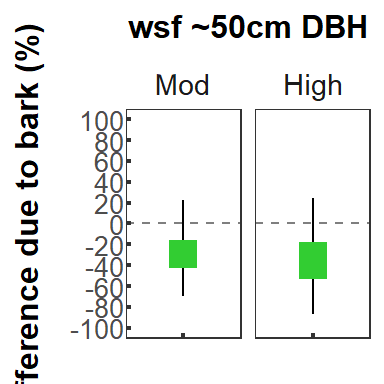

```r
My_Theme = theme(
  plot.title = element_text(size = 12, face = "bold", hjust = 0.5),
  axis.title.y = element_text(size = 12, face = "bold"),
  axis.text.y = element_text(size = 10, margin = unit(c(0.1, 0.1, 0.1, -0.2), "cm")),
  axis.text.x = element_blank(),
  axis.title.x = element_text(size = 12, face = "bold", vjust = -0.6),
  strip.text.x = element_text(size = 11),
  strip.text.y = element_text(size = 11),
  strip.text = element_text(size = 11),
  strip.background = element_blank(),
  panel.background = element_blank(),
  strip.placement = "inside",
  axis.ticks.length = unit(-0.07, "cm"),
  axis.ticks = element_line(size = 0.8),
  panel.grid.minor.x = element_blank(),
  panel.grid.major.x = element_blank(),
  panel.grid.minor.y = element_blank(),
  panel.grid.major.y = element_blank(),
  legend.position = "bottom",
  legend.title = element_text(size = 9, hjust = 0.6, face = "bold"),
  legend.text = element_text(size = 9),
  legend.key.width = unit(0.3, "cm"),
  legend.key.height = unit(0.5, "cm"),
  legend.background = element_blank(),
  plot.margin = unit(c(5, 5, 5, 5), "pt"))


diff.lrg.group.wsf <- ggplot(data = x.stats1.group.lrg, aes(x = group)) +

  My_Theme +

  geom_linerange(aes(ymin = lwr95, ymax = upr95),
               size = 0.5, position = position_dodge(width = 0.6)) +

  geom_linerange(aes(ymin = lwr50, ymax = upr50),
               size = 5.0, show.legend = FALSE, position = position_dodge(width = 0.6), col = "limegreen") +


  labs(x = "", y = "Difference due to bark (%)\n", title = "wsf ~50cm DBH") +


  geom_hline(yintercept = 0, linetype = "dashed", alpha = 0.5) +


  scale_y_continuous(labels = scales::percent_format(suffix = "", accuracy = 1), limits = c(-1, 1), breaks = c(-1, -0.8, -0.6, -0.4, -0.2, 0, 0.2, 0.4, 0.6, 0.8, 1)) +
  coord_cartesian(ylim=c(-1, 1)) +

  facet_grid(~ sev)

diff.lrg.group.wsf
```

Change in difference for 50 cm trees

```r
dat.gg1.group.lrg %>%
  group_by(sev, group) %>%
  summarize(prob = mean(diff))
```

```
## # A tibble: 2 x 3
## # Groups:   sev [2]
##   sev   group   prob
##   <fct> <fct>  <dbl>
## 1 Mod   group -0.248
## 2 High  group -0.331
```

```r
x.stats1.group.lrg
```

```
## # A tibble: 2 x 7
## # Groups:   sev [2]
##   sev   group    mid  lwr95 upr95  lwr50  upr50
##   <fct> <fct>  <dbl>  <dbl> <dbl>  <dbl>  <dbl>
## 1 Mod   group -0.261 -0.691 0.229 -0.426 -0.162
## 2 High  group -0.353 -0.871 0.249 -0.530 -0.181
```